# TP modèles linéaires - Partie 2

4modIA - 2023-2024

L’objectif de ce TP est d’illustrer les notions abordées dans les chapitres dédiés à l’ANOVA et l’ANCOVA.

Les librairies R nécessaires pour ce TP sont :

```r
library(ggplot2)
library(tidyverse)
```

# 1 Description du jeu de données

Nous allons reprendre le jeu de données “Ozone.txt” contenant 112 mesures de concentration d’ozone (en $\mu$gr/m3) et différentes variables observées, recueillies à Rennes durant l’été 2001. Les 13 variables observées sont :

- maxO3 : Maximum de concentration d’ozone observé sur la journée en $\mu$gr/m3
- T9, T12, T15 : Température observée à 9, 12 et 15h
- Ne9, Ne12, Ne15 : Nébulosité observée à 9, 12 et 15h
- Vx9, Vx12, Vx15 : Composante E-O du vent à 9, 12 et 15h
- maxO3v : Teneur maximum en ozone observée la veille
- vent : orientation du vent à 12h
- pluie : occurrence ou non de précipitations

```r
ozone = read.table("Ozone.txt")
ozone$vent = as.factor(ozone$vent)
ozone$pluie = as.factor(ozone$pluie)
head(ozone)
```

```
         maxO3   T9  T12  T15 Ne9 Ne12 Ne15     Vx9    Vx12    Vx15 maxO3v
20010601    87 15.6 18.5 18.4   4    4    8  0.6946 -1.7101 -0.6946     84
20010602    82 17.0 18.4 17.7   5    5    7 -4.3301 -4.0000 -3.0000     87
20010603    92 15.3 17.6 19.5   2    5    4  2.9544  1.8794  0.5209     82
20010604   114 16.2 19.7 22.5   1    1    0  0.9848  0.3473 -0.1736     92
20010605    94 17.4 20.5 20.4   8    8    7 -0.5000 -2.9544 -4.3301    114
20010606    80 17.7 19.8 18.3   6    6    7 -5.6382 -5.0000 -6.0000     94
          vent pluie
20010601  Nord   Sec
20010602  Nord   Sec
20010603   Est   Sec
20010604  Nord   Sec
20010605 Ouest   Sec
20010606 Ouest Pluie
```

```r
summary(ozone[, c(1, 11, 12, 13)])
```

```
     maxO3            maxO3v          vent      pluie
 Min.   : 42.00   Min.   : 42.00   Est  :10   Pluie:43
 1st Qu.: 70.75   1st Qu.: 71.00   Nord :31   Sec  :69
 Median : 81.50   Median : 82.50   Ouest:50
 Mean   : 90.30   Mean   : 90.57   Sud  :21
 3rd Qu.:106.00   3rd Qu.:106.00
 Max.   :166.00   Max.   :166.00
```

# 2 Analyse de la variance

## 2.1 ANOVA à un facteur

Dans cette section, nous souhaitons analyser la relation entre la concentration maximale d’ozone (maxO3) et la direction du vent (vent). On va pour cela mettre en place un modèle d’anova à un facteur

$$\left\{\begin{array}{l} maxO3_{ij}= \mu + \alpha_i +\varepsilon_{ij},\ \
i=1,\ldots,I=4,\ j=1,\ldots,n_i.\\ (\varepsilon_{ij})_{i,j} \textrm{
i.i.d
}\mathcal{N}(0,\sigma^2) \end{array}\right.$$
1. Représentez la concentration maximale d’ozone en fonction du vent. Commentez

```r
# A COMPLETER
```

2. Utilisez la fonction `lm()` pour ajuster un modèle d’ANOVA à un facteur. Commentez.

Interprétez en particulier les pvaleurs $0.7700$ et $0.02074$.

```r
aovent <- lm(.....)
```

3. A l’aide de la fonction `anova()`, testez la significativité du facteur vent. Commentez.

```r
# A COMPLETER
```

4. On s’intéresse ici à l’estimation des paramètres.
- Comparez les différents résultats obtenus par les commandes suivantes.
- Vérifiez mathématiquement et numériquement les estimations des paramètres. Vous pourrez utiliser `Yi. = by(ozone[,"maxO3"],ozone[,"vent"],mean)`.

```r
summary(lm(maxO3 ~ vent, data = ozone))
```

```
Call:
lm(formula = maxO3 ~ vent, data = ozone)

Residuals:
    Min      1Q  Median      3Q     Max
-60.600 -16.807  -7.365  11.478  81.300

Coefficients:
            Estimate Std. Error t value Pr(>|t|)
(Intercept)  105.600      8.639  12.223   <2e-16 ***
ventNord     -19.471      9.935  -1.960   0.0526 .
ventOuest    -20.900      9.464  -2.208   0.0293 *
ventSud       -3.076     10.496  -0.293   0.7700
---
Signif. codes:  0 '***' 0.001 '**' 0.01 '*' 0.05 '.' 0.1 ' ' 1

Residual standard error: 27.32 on 108 degrees of freedom
Multiple R-squared:  0.08602,   Adjusted R-squared:  0.06063
F-statistic: 3.388 on 3 and 108 DF,  p-value: 0.02074
```

```r
summary(lm(maxO3 ~ C(vent, base = 2), data = ozone))
```

```
Call:
lm(formula = maxO3 ~ C(vent, base = 2), data = ozone)

Residuals:
    Min      1Q  Median      3Q     Max
-60.600 -16.807  -7.365  11.478  81.300

Coefficients:
                   Estimate Std. Error t value Pr(>|t|)
(Intercept)          86.129      4.907  17.553   <2e-16 ***
C(vent, base = 2)1   19.471      9.935   1.960   0.0526 .
C(vent, base = 2)3   -1.429      6.245  -0.229   0.8194
C(vent, base = 2)4   16.395      7.721   2.123   0.0360 *
---
Signif. codes:  0 '***' 0.001 '**' 0.01 '*' 0.05 '.' 0.1 ' ' 1

Residual standard error: 27.32 on 108 degrees of freedom
Multiple R-squared:  0.08602,   Adjusted R-squared:  0.06063
F-statistic: 3.388 on 3 and 108 DF,  p-value: 0.02074
```

```r
summary(lm(maxO3 ~ C(vent, sum), data = ozone))
```

```
Call:
lm(formula = maxO3 ~ C(vent, sum), data = ozone)

Residuals:
    Min      1Q  Median      3Q     Max
-60.600 -16.807  -7.365  11.478  81.300

Coefficients:
              Estimate Std. Error t value Pr(>|t|)
(Intercept)     94.738      3.053  31.027   <2e-16 ***
C(vent, sum)1   10.862      6.829   1.590   0.1147
C(vent, sum)2   -8.609      4.622  -1.863   0.0652 .
C(vent, sum)3  -10.038      4.097  -2.450   0.0159 *
---
Signif. codes:  0 '***' 0.001 '**' 0.01 '*' 0.05 '.' 0.1 ' ' 1

Residual standard error: 27.32 on 108 degrees of freedom
Multiple R-squared:  0.08602,   Adjusted R-squared:  0.06063
F-statistic: 3.388 on 3 and 108 DF,  p-value: 0.02074
```

5. Au vu des différentes conclusions, quelle modification de la variable vent peut-on considérer pour expliquer la concentration en ozone ? Vérifiez numériquement votre proposition.

## 2.2 ANOVA à deux facteurs

Dans cette section, nous souhaitons analyser la relation entre la concentration maximale d’ozone (maxO3) avec la direction du vent (vent) et la précipitation (pluie). On va donc mettre en place un modèle d’analyse de la variance à deux facteurs.

1. Représentez la concentration en ozone pour chaque modalité croisée du vent et de la pluie à l’aide de la commande suivante et commentez.

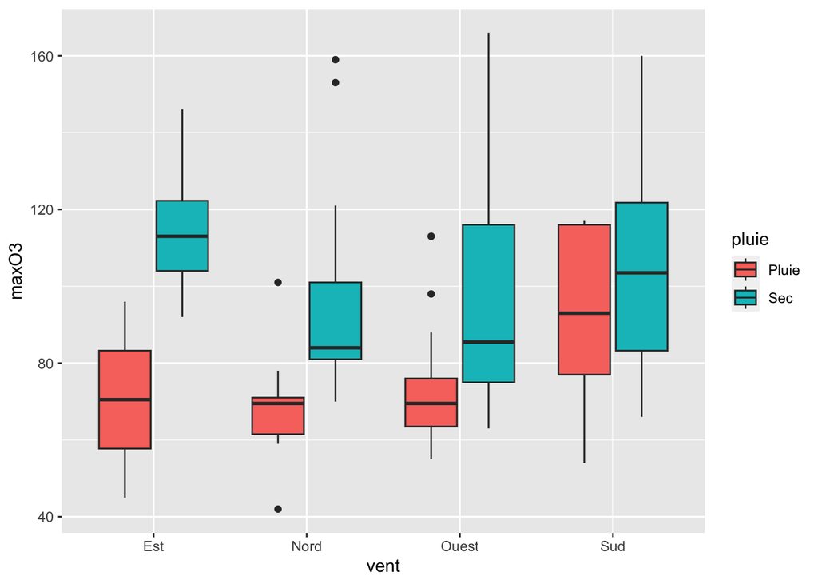

```r
ggplot(ozone, aes(x = vent, y = maxO3, fill = pluie)) + geom_boxplot()
```

Une autre façon d’analyser graphiquement l’interaction est la suivante :

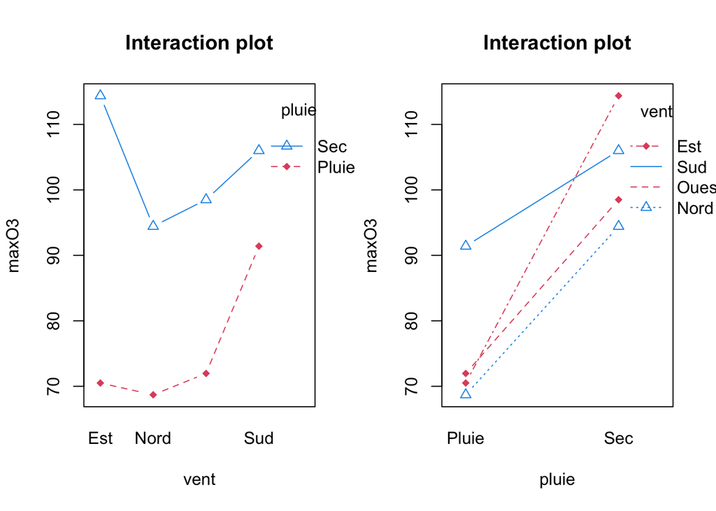

```r
par(mfrow = c(1, 2))
interaction.plot(ozone[, "vent"], ozone[, "pluie"], ozone[, "maxO3"], col = c(2,
    4), pch = c(18, 24), main = "Interaction plot", type = "b", xlab = "vent", ylab = "maxO3",
    trace.label = "pluie")
interaction.plot(ozone[, "pluie"], ozone[, "vent"], ozone[, "maxO3"], col = c(2,
    4), pch = c(18, 24), main = "Interaction plot", type = "b", xlab = "pluie", ylab = "maxO3",
    trace.label = "vent")
```

2. Mettez en place un modèle d’analyse de la variance avec interaction. Commentez les résultats.

```r
mod.int <- lm(...)  # A COMPLETER
summary(mod.int)
```

3. A l’aide de la fonction `anova()`, testez si l’on peut simplifier ce modèle d’ANOVA à deux facteurs avec interaction.

```r
# A COMPLETER
```

4. Reprenez les questions 1. et 2. en considérant les regroupements de modalités de la variable vent comme en section 2.1, question 5.

# 3 Analyse de la covariance

Dans cette partie, on s’intéresse à la relation du taux maximal d’ozone (maxO3) par rapport à celui de la veille (maxO3v) et en fonction des précipitations (pluie). Pour cela, on va mettre en place un modèle d’analyse de la covariance.

1. A l’aide des commandes suivantes, représentez le nuage de points entre la variable à expliquer et la variable quantitative explicative, en fonction des modalités de la variable qualitative. Commentez.

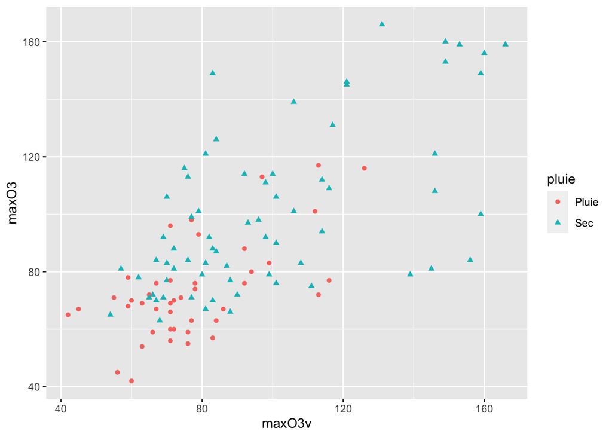

```r
ggplot(ozone, aes(x = maxO3v, y = maxO3)) + geom_point(aes(shape = pluie, col = pluie))
```

2. On ajuste un modèle d’analyse de covariance complet. Ecrivez le modèle mathématiquement (version régulière et version singulière), et commentez les résultats obtenus.

```r
# version singulière
complet = lm(maxO3 ~ pluie * maxO3v, data = ozone)
summary(complet)
```

```
Call:
lm(formula = maxO3 ~ pluie * maxO3v, data = ozone)

Residuals:
    Min      1Q  Median      3Q     Max
-50.750 -11.932  -0.926  11.695  57.612

Coefficients:
                Estimate Std. Error t value Pr(>|t|)
(Intercept)     30.24498   12.75140   2.372 0.019467 *
pluieSec        11.84247   15.17665   0.780 0.436916
maxO3v           0.55904    0.16055   3.482 0.000719 ***
pluieSec:maxO3v  0.03494    0.17923   0.195 0.845786
---
Signif. codes:  0 '***' 0.001 '**' 0.01 '*' 0.05 '.' 0.1 ' ' 1

Residual standard error: 19.71 on 108 degrees of freedom
Multiple R-squared:  0.5244,    Adjusted R-squared:  0.5112
F-statistic:  39.7 on 3 and 108 DF,  p-value: < 2.2e-16
```

```r
# version régulière
alt = lm(maxO3 ~ -1 + pluie + pluie:maxO3v, data = ozone)
summary(alt)
```

```
Call:
lm(formula = maxO3 ~ -1 + pluie + pluie:maxO3v, data = ozone)

Residuals:
    Min      1Q  Median      3Q     Max
-50.750 -11.932  -0.926  11.695  57.612

Coefficients:
                  Estimate Std. Error t value Pr(>|t|)
pluiePluie        30.24498   12.75140   2.372 0.019467 *
pluieSec          42.08745    8.22997   5.114 1.38e-06 ***
pluiePluie:maxO3v  0.55904    0.16055   3.482 0.000719 ***
pluieSec:maxO3v    0.59399    0.07967   7.455 2.37e-11 ***
---
Signif. codes:  0 '***' 0.001 '**' 0.01 '*' 0.05 '.' 0.1 ' ' 1

Residual standard error: 19.71 on 108 degrees of freedom
Multiple R-squared:  0.9581,    Adjusted R-squared:  0.9566
F-statistic: 617.7 on 4 and 108 DF,  p-value: < 2.2e-16
```

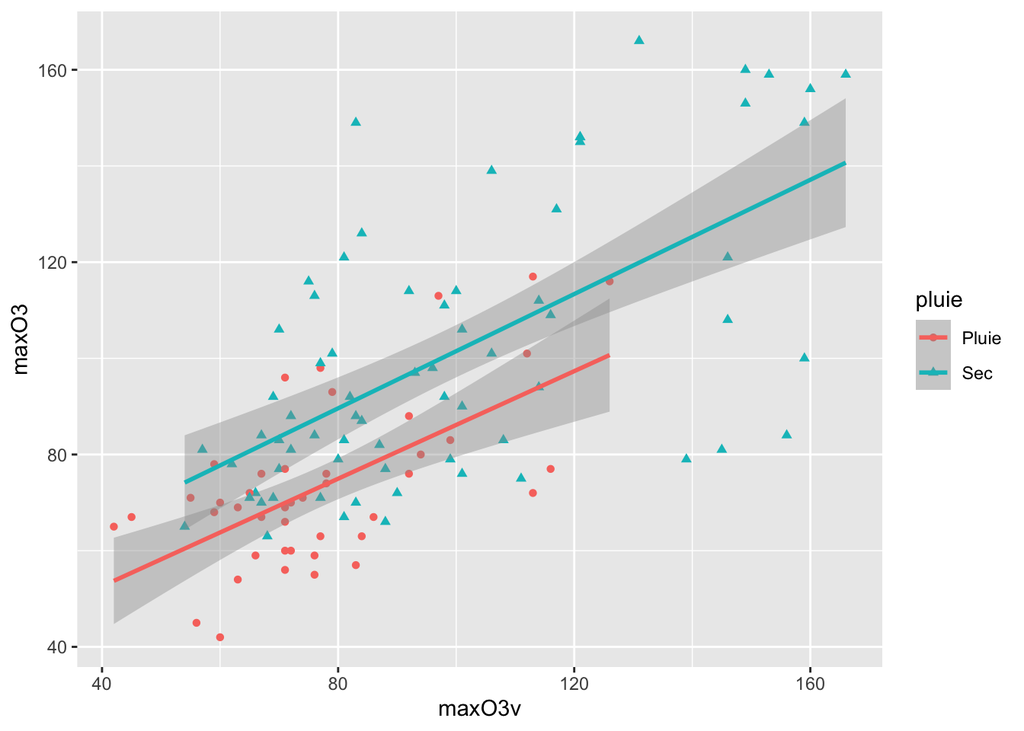

```r
ggplot(ozone, aes(x = maxO3v, y = maxO3, shape = pluie, col = pluie)) + geom_point() +
    geom_smooth(method = "lm", se = T)
```

3. Les commandes suivantes permettent de tester l’égalité des pentes. Ecrivez les modèles en compétition et commentez les résultats.

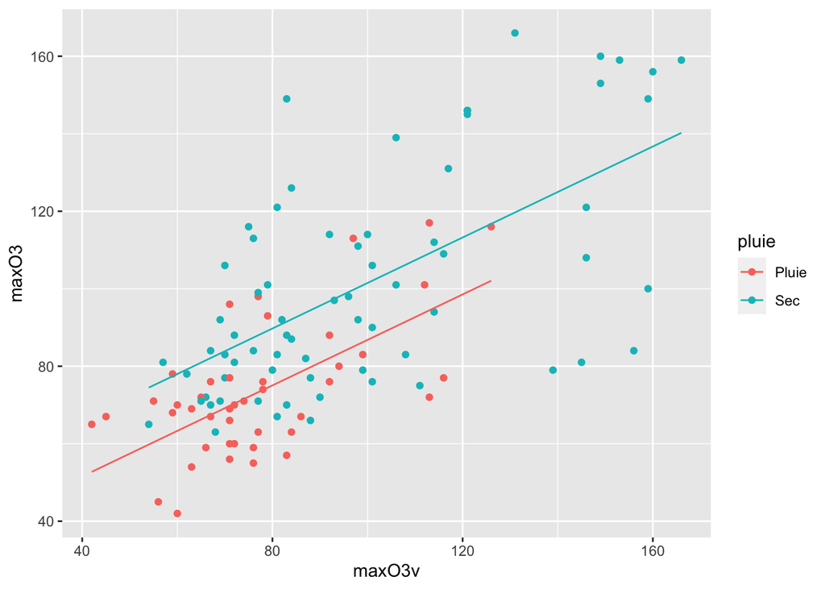

```r
penteu = lm(maxO3 ~ -1 + pluie + maxO3v, data = ozone)
predm1 = predict(penteu)
ggplot(ozone, aes(maxO3v, maxO3, color = pluie)) + geom_point() + geom_line(aes(y = predm1))
```

```r
anova(penteu, complet)
```

```
Analysis of Variance Table

Model 1: maxO3 ~ -1 + pluie + maxO3v
Model 2: maxO3 ~ pluie * maxO3v
  Res.Df   RSS Df Sum of Sq     F Pr(>F)
1    109 41957
2    108 41943  1    14.762 0.038 0.8458
```

4. On souhaite ici comparer un modèle avec pente commune contre un modèle de régression linéaire simple. Commentez les résultats.

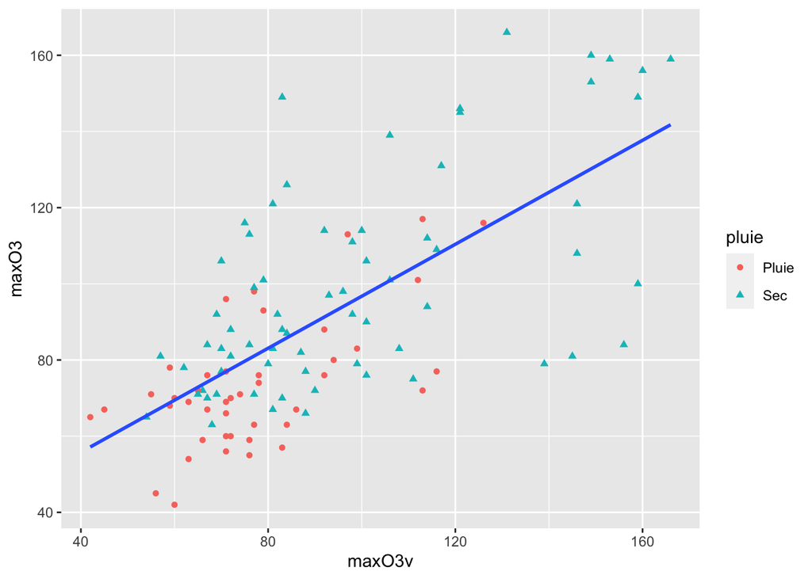

```r
simple = lm(maxO3 ~ maxO3v, data = ozone)
ggplot(ozone, aes(x = maxO3v, y = maxO3)) + geom_point(aes(shape = pluie, col = pluie)) +
    geom_smooth(method = "lm", se = F)
```

```r
anova(simple, penteu)
```

```
Analysis of Variance Table

Model 1: maxO3 ~ maxO3v
Model 2: maxO3 ~ -1 + pluie + maxO3v
  Res.Df   RSS Df Sum of Sq      F    Pr(>F)
1    110 46868
2    109 41957  1      4911 12.758 0.0005291 ***
---
Signif. codes:  0 '***' 0.001 '**' 0.01 '*' 0.05 '.' 0.1 ' ' 1
```

# 4 A vous de jouer!

Dans cette partie, je vous propose quelques jeux de données pour mettre en pratique les notions vues dans les deux TP consacrés au modèle linéaire. A vous de choisir le modèle linéaire adapté à chacun des problèmes et de mener une analyse statistique pertinente.

## 4.1 Hauteur des eucalyptus

Dans le jeu de données “eucalyptus.txt”, on dispose de la circonférence et de la hauteur de 1429 eucalyptus.

Expliquez la hauteur des eucalyptus en fonction de la circonférence. On pourra aussi s’intéresser à un modèle expliquant la hauteur en fonction de la circonférence et de la racine de la circonférence.

## 4.2 Rendement des tomates

A partir du jeu de données “tomates.csv”, étudiez le lien entre le rendement des pieds de tomates, la parcelle dans laquelle ils ont été cultivés et le traitement reçu.

## 4.3 Cidres

Dans le fichier “cidre.csv”, on dispose de l’évaluation de la saveur sucrée et de la saveur amère fournie par un jury sensoriel pour chacun des 50 cidres bruts, 30 cidres demi-secs et 10 cidres doux. Etudiez la relation entre la saveur sucrée et la saveur amère en fonction du type de cidre.